# Exercise Manner Prediction Assignment

Geoffrey Smith

July 21, 2015

## Executive Summary

This report serves as an investigation and analysis of quantified self movement data in an effort to predict the manner in which an exercise has been performed. I will show that using a random forests model we will be able to provide an accurate prediction of the classe.

## Libraries

```r
library(caret)
library(corrplot)
library(kernlab)
library(randomForest)
```

## Data processing

Load and clean training data.

```r
training <- read.csv("./pml-training.csv", na.strings=c("NA",""," "))
trainingNAs <- apply(training, 2, function(x) {sum(is.na(x))}) #find NAs
trainingClean <- training[,which(trainingNAs == 0)] #remove NAs
trainingClean <- trainingClean[8:length(trainingClean)] #remove first eight identifier columns
```

Load and clean testing data.

```r
testing <- read.csv("./pml-testing.csv", na.strings=c("NA",""," "))
testingNAs <- apply(testing, 2, function(x) {sum(is.na(x))}) #find NAs
testingClean <- testing[,which(testingNAs == 0)] #remove NAs
testingClean <- testingClean[8:length(testingClean)] #remove first eight identifier columns
testing <- testingClean
```

Split cleaned training data for cross validation.

```r
inTrain <- createDataPartition(y=trainingClean$classe, p=0.7, list=F)
training <- trainingClean[inTrain,]
crossval <- trainingClean[-inTrain,]
```

## Data exploration

Plot correlation matrix to view variable relationships and identify highly correlated predictors. We can see from the figure below that there are few highly correlated predictors - We will thus include all predictors in the model.

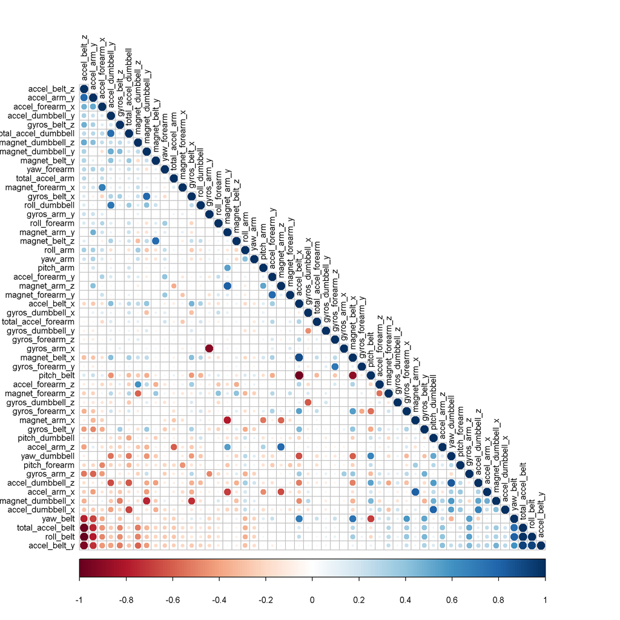

```r
corrMatrix <- cor(training[, -length(training)])
corrplot(corrMatrix, order="FPC", method="circle", type="lower", tl.cex=0.8, tl.col=rgb(0,0,0))
```

## Model fit

A random forest model will be fitted. Random forests handles unbalanced and low correlated data well.

```r
modelFit <- randomForest(classe ~ ., data=training)
modelFit
```

```
##
## Call:
##  randomForest(formula = classe ~ ., data = training)
##                Type of random forest: classification
##                      Number of trees: 500
## No. of variables tried at each split: 7
##
##         OOB estimate of  error rate: 0.52%
## Confusion matrix:
##      A    B    C    D    E  class.error
## A 3904    2    0    0    0 0.0005120328
## B    9 2642    7    0    0 0.0060195636
## C    0   15 2377    4    0 0.0079298831
## D    0    0   24 2227    1 0.0111012433
## E    0    0    1    8 2516 0.0035643564
```

We can see that the error rate estimate is quite low, around 0.5%. We would expect the out of sample error rate to be similar, if not slightly higher than this.

## Cross validation

We now cross validate the model using a confusion matrix in order to determine the accuracy.

```r
predictCrossVal <- predict(modelFit, crossval)
confusionMatrix(crossval$classe, predictCrossVal)
```

```
## Confusion Matrix and Statistics
##
##           Reference
## Prediction    A    B    C    D    E
##          A 1673    0    0    0    1
##          B    5 1131    3    0    0
##          C    0   11 1015    0    0
##          D    0    0   12  952    0
##          E    0    0    0    8 1074
##
## Overall Statistics
##
##                Accuracy : 0.9932
##                  95% CI : (0.9908, 0.9951)
##     No Information Rate : 0.2851
##     P-Value [Acc > NIR] : < 2.2e-16
##
##                   Kappa : 0.9914
##  Mcnemar's Test P-Value : NA
##
## Statistics by Class:
##
##                      Class: A Class: B Class: C Class: D Class: E
## Sensitivity            0.9970   0.9904   0.9854   0.9917   0.9991
## Specificity            0.9998   0.9983   0.9977   0.9976   0.9983
## Pos Pred Value         0.9994   0.9930   0.9893   0.9876   0.9926
## Neg Pred Value         0.9988   0.9977   0.9969   0.9984   0.9998
## Prevalence             0.2851   0.1941   0.1750   0.1631   0.1827
## Detection Rate         0.2843   0.1922   0.1725   0.1618   0.1825
## Detection Prevalence   0.2845   0.1935   0.1743   0.1638   0.1839
## Balanced Accuracy      0.9984   0.9943   0.9916   0.9946   0.9987
```

## Prediction

Apply model against testing data set to predict the classe.

```r
predictTesting <- predict(modelFit, testing)
predictTesting
```

```
##  1  2  3  4  5  6  7  8  9 10 11 12 13 14 15 16 17 18 19 20
##  B  A  B  A  A  E  D  B  A  A  B  C  B  A  E  E  A  B  B  B
## Levels: A B C D E
```

## Conclusion

The random forest model was able to provide a very accurate prediction of classe based on the use of all of the available parameters.